# hw3 stat128

Author

Austin Melendez

```r
#install.packages("tidyverse")
library(tidyverse)
library(tidyr)
library(dplyr)
```

Questions on this homework are intentionally becoming more high level, and have multiple interpretations. For example, for the question “what were the 5 most popular songs”, you will have to define a reasonable metric for popularity.

## 1. Billboard

The following questions refer to the `billboard` dataset from the tidyr package.

#### 1. What period does the data cover?

```r
billboard |>
  pull(date.entered) |>
  unique() |>
  sort()
```

```
 [1] "1999-06-05" "1999-07-17" "1999-09-04" "1999-09-11" "1999-10-09"
 [6] "1999-10-16" "1999-10-23" "1999-10-30" "1999-11-06" "1999-11-13"
[11] "1999-11-20" "1999-11-27" "1999-12-04" "1999-12-11" "1999-12-18"
[16] "1999-12-25" "2000-01-01" "2000-01-08" "2000-01-15" "2000-01-22"
[21] "2000-01-29" "2000-02-05" "2000-02-12" "2000-02-19" "2000-02-26"
[26] "2000-03-04" "2000-03-11" "2000-03-18" "2000-03-25" "2000-04-01"
[31] "2000-04-08" "2000-04-15" "2000-04-22" "2000-04-29" "2000-05-06"
[36] "2000-05-13" "2000-05-20" "2000-05-27" "2000-06-03" "2000-06-10"
[41] "2000-06-17" "2000-06-24" "2000-07-01" "2000-07-08" "2000-07-15"
[46] "2000-07-22" "2000-07-29" "2000-08-05" "2000-08-12" "2000-08-19"
[51] "2000-08-26" "2000-09-02" "2000-09-09" "2000-09-16" "2000-09-23"
[56] "2000-09-30" "2000-10-07" "2000-10-14" "2000-10-21" "2000-10-28"
[61] "2000-11-04" "2000-11-11" "2000-11-18" "2000-11-25" "2000-12-02"
[66] "2000-12-16" "2000-12-23" "2000-12-30"
```

This dataset actually covers from 06/05/1999 to 12/30/2000.

#### 2. Is the data complete for the year 2000?

```r
billboard |>
  filter(year(date.entered) == 2000) |>
  pull(date.entered) |>
  unique() |>
  sort()
```

```
 [1] "2000-01-01" "2000-01-08" "2000-01-15" "2000-01-22" "2000-01-29"
 [6] "2000-02-05" "2000-02-12" "2000-02-19" "2000-02-26" "2000-03-04"
[11] "2000-03-11" "2000-03-18" "2000-03-25" "2000-04-01" "2000-04-08"
[16] "2000-04-15" "2000-04-22" "2000-04-29" "2000-05-06" "2000-05-13"
[21] "2000-05-20" "2000-05-27" "2000-06-03" "2000-06-10" "2000-06-17"
[26] "2000-06-24" "2000-07-01" "2000-07-08" "2000-07-15" "2000-07-22"
[31] "2000-07-29" "2000-08-05" "2000-08-12" "2000-08-19" "2000-08-26"
[36] "2000-09-02" "2000-09-09" "2000-09-16" "2000-09-23" "2000-09-30"
[41] "2000-10-07" "2000-10-14" "2000-10-21" "2000-10-28" "2000-11-04"
[46] "2000-11-11" "2000-11-18" "2000-11-25" "2000-12-02" "2000-12-16"
[51] "2000-12-23" "2000-12-30"
```

```r
billboard |>
  mutate(
    date = date.entered + week(date.entered)
  ) |>
  filter(year(date) == 2000) |>
  group_by(date) |>
  summarize(n())
```

```
# A tibble: 52 × 2
   date       `n()`
   <date>     <int>
 1 2000-01-02     4
 2 2000-01-06     4
 3 2000-01-10     3
 4 2000-01-14     6
 5 2000-01-18     4
 6 2000-01-22     8
 7 2000-01-26     7
 8 2000-01-30     5
 9 2000-02-03    11
10 2000-02-07     2
# ℹ 42 more rows
```

No, the data is not complete because there are not 100 songs listed for every week for the year 2000.

#### 3. What were the 5 most popular songs?

Answer by creating and commenting on a data visualization.

```r
billboard |>
  pivot_longer(
    cols = starts_with("wk"),
    names_to = "week",
    values_to = "rank",
    values_drop_na = TRUE
  ) |>
  group_by(track) |>
  summarize(
    avg_rank = mean(rank),
    weeks_long = n()
  ) |>
  arrange(avg_rank) |>
  head()
```

```
# A tibble: 6 × 3
  track                   avg_rank weeks_long
  <chr>                      <dbl>      <int>
1 Maria, Maria                10.5         26
2 Music                       13.5         24
3 Bye Bye Bye                 14.3         23
4 Hot Boyz                    14.3         21
5 Independent Women Pa...     14.8         28
6 Be With You                 15.8         20
```

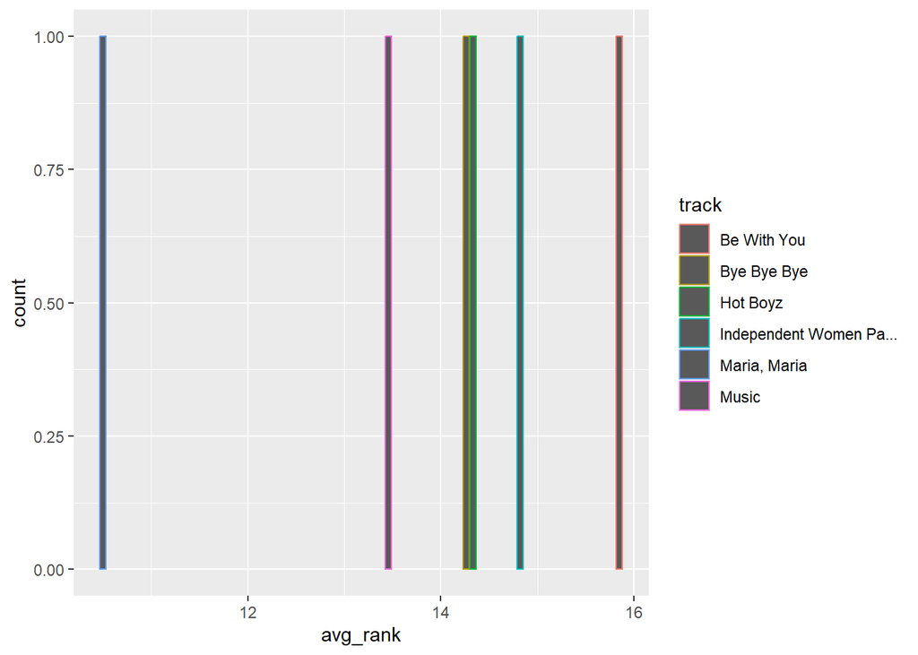

```r
billboard |>
  pivot_longer(
    cols = starts_with("wk"),
    names_to = "week",
    values_to = "rank",
    values_drop_na = TRUE
  ) |>
  group_by(track) |>
  summarize(
    avg_rank = mean(rank),
    weeks_long = n()
  ) |>
  arrange(avg_rank) |>
  head() |>
  ggplot(aes(x = avg_rank)) +
  geom_bar(aes(color = track))
```

#### 4. On average, how long does a song stay in the top 100?

```r
billboard |>
  pivot_longer(
    cols = starts_with("wk"),
    names_to = "week",
    values_to = "rank",
    values_drop_na = TRUE
  ) |>
  group_by(track) |>
  summarize(
    weeks_long = n()
  ) |>
  mutate(
    avg_weeks = mean(weeks_long)
  )
```

```
# A tibble: 316 × 3
   track                   weeks_long avg_weeks
   <chr>                        <int>     <dbl>
 1 (Hot S**t) Country G...         34      16.8
 2 3 Little Words                   9      16.8
 3 911                             19      16.8
 4 A Country Boy Can Su...          3      16.8
 5 A Little Gasoline                6      16.8
 6 A Puro Dolor (Purest...         26      16.8
 7 Aaron's Party (Come ...         15      16.8
 8 Absolutely (Story Of...         27      16.8
 9 All Good?                        3      16.8
10 All The Small Things            23      16.8
# ℹ 306 more rows
```

On average, a song stays in the top 100 for just over 16 weeks.

#### 5. Pick three songs that reached number one and visualize the “popularity trajectory” of their ranking over time.

Comment on your visualization and explain it to a general audience. Do some songs appear to gain and lose popularity more quickly than others? [Maria Maria, Say My Name, It’s Gonna Be Me]

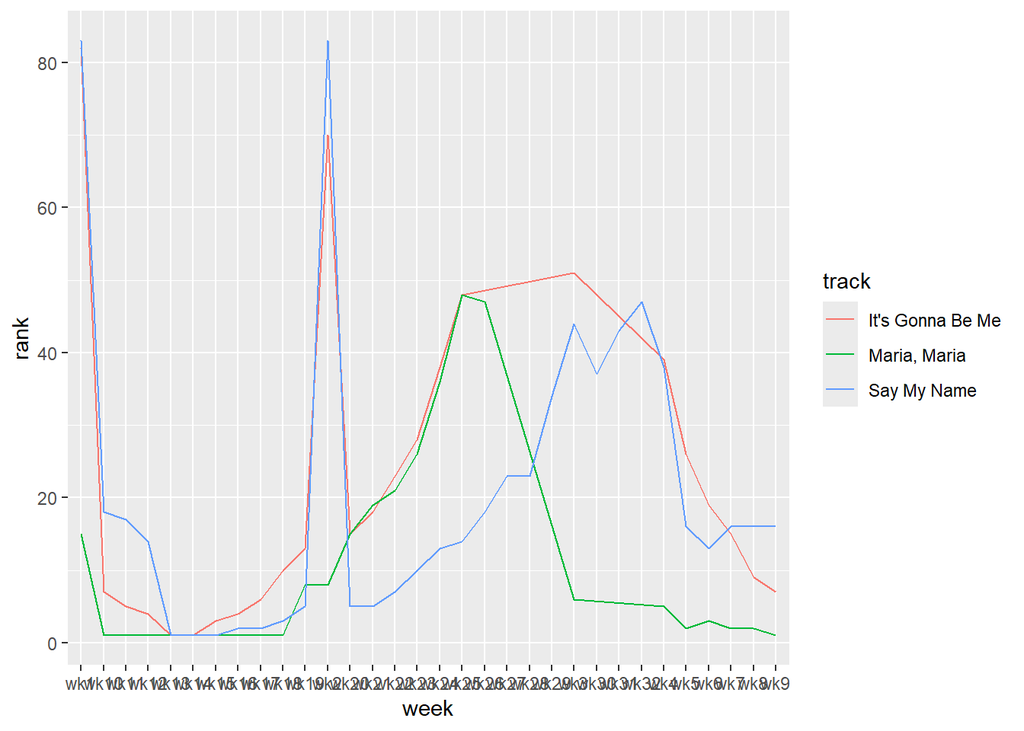

```r
billboard |>
    pivot_longer(
    cols = starts_with("wk"),
    names_to = "week",
    values_to = "rank",
    values_drop_na = TRUE
  ) |>
  group_by(track) |>
  filter(track == "Maria, Maria" | track == "Say My Name" | track == "It's Gonna Be Me") |>
  ggplot(aes(x = week, y = rank, color = track, group = track)) +
  geom_line()
```

## 2. World Bank

The following questions refer to the `world_bank_pop` dataset in the tidyr package. I suggest you use the [countrycode package](https://cran.r-project.org/package=countrycode) to find country names.

#### 1. Use the country abbreviation to join the country names to the data.

```r
#install.packages("countrycode")
library("countrycode")

abbr_key <- pull(world_bank_pop, country)
abbr_key <- unique(abbr_key)

country_names <- countrycode(abbr_key, origin="iso3c", destination="country.name", nomatch = NULL)

abbr_key <- data.frame(abbr=abbr_key, name=unique(country_names))

df <- inner_join(world_bank_pop, abbr_key, by = join_by(country == abbr)) |>
  relocate(name)

df
```

```
# A tibble: 1,064 × 21
   name        country indicator  `2000`  `2001`  `2002`  `2003`  `2004`  `2005`
   <chr>       <chr>   <chr>       <dbl>   <dbl>   <dbl>   <dbl>   <dbl>   <dbl>
 1 Aruba       ABW     SP.URB.TO… 4.16e4 4.20e+4 4.22e+4 4.23e+4 4.23e+4 4.24e+4
 2 Aruba       ABW     SP.URB.GR… 1.66e0 9.56e-1 4.01e-1 1.97e-1 9.46e-2 1.94e-1
 3 Aruba       ABW     SP.POP.TO… 8.91e4 9.07e+4 9.18e+4 9.27e+4 9.35e+4 9.45e+4
 4 Aruba       ABW     SP.POP.GR… 2.54e0 1.77e+0 1.19e+0 9.97e-1 9.01e-1 1.00e+0
 5 AFE         AFE     SP.URB.TO… 1.16e8 1.20e+8 1.24e+8 1.29e+8 1.34e+8 1.39e+8
 6 AFE         AFE     SP.URB.GR… 3.60e0 3.66e+0 3.72e+0 3.71e+0 3.74e+0 3.81e+0
 7 AFE         AFE     SP.POP.TO… 4.02e8 4.12e+8 4.23e+8 4.34e+8 4.45e+8 4.57e+8
 8 AFE         AFE     SP.POP.GR… 2.58e0 2.59e+0 2.61e+0 2.62e+0 2.64e+0 2.67e+0
 9 Afghanistan AFG     SP.URB.TO… 4.31e6 4.36e+6 4.67e+6 5.06e+6 5.30e+6 5.54e+6
10 Afghanistan AFG     SP.URB.GR… 1.86e0 1.15e+0 6.86e+0 7.95e+0 4.59e+0 4.47e+0
# ℹ 1,054 more rows
# ℹ 12 more variables: `2006` <dbl>, `2007` <dbl>, `2008` <dbl>, `2009` <dbl>,
#   `2010` <dbl>, `2011` <dbl>, `2012` <dbl>, `2013` <dbl>, `2014` <dbl>,
#   `2015` <dbl>, `2016` <dbl>, `2017` <dbl>
```

#### 2. How has the total population changed for the 5 largest countries?

Answer by creating and commenting on a data visualization using the relative growth. Use country names, not abbreviations.

```r
tot_pop <- filter(df, indicator == "SP.POP.TOTL")
pop_grow <- filter(df, indicator == "SP.POP.GROW")
pop_grow <- subset(pop_grow, select = -c(country,indicator) )

tot_pop <- subset(tot_pop, select = c("name","2017"))

#Had to find this function on dyplr becuase of an update with R on sorting
#https://help.displayr.com/hc/en-us/articles/7150750270095-Changes-in-R-Version-4-3-0
data.matrix = as.matrix(tot_pop)
order.of.columns = order(data.matrix[,2], decreasing = TRUE)
sorted.df = tot_pop[order.of.columns, ]

sorted.df
```

```
# A tibble: 266 × 2
   name      `2017`
   <chr>      <dbl>
 1 WLD   7578157615
 2 IBT   6401367406
 3 LMY   6322861019
 4 MIC   5679375318
 5 IBD   4776473096
 6 EAR   3252529883
 7 LMC   3225575822
 8 UMC   2453799496
 9 EAS   2327134580
10 LTE   2286564636
# ℹ 256 more rows
```

The three biggest countries that were translated to actual country names were China (1396215000), India (1354195680), and United States (325122128).

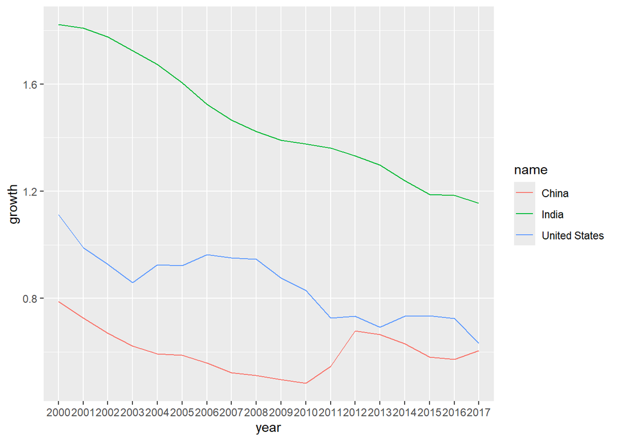

```r
pop_grow |>
  filter(name == "China" | name == "India" | name == "United States") |>
  pivot_longer(
    cols = !name,
    names_to = "year",
    values_to = "growth"
  ) |>
  ggplot(aes(x = year, y = growth, color = name, group = name)) +
  geom_line()
```

All three of the largest countries have had an overall declining population growth during the dataset time frame (2000 - 2017).

## 3. Your own question

**How does 5 random countries urban population growth compare to their overall total population?**

```r
tot_pop <- filter(df, indicator == "SP.POP.TOTL")
urb_grow <- filter(df, indicator == "SP.URB.GROW")
tot_pop <- subset(tot_pop, select = -c(country,indicator))
urb_grow <- subset(urb_grow, select = -c(country,indicator))

rand <- sample(1:266, 5)
country_names <- data.frame(country_names)
country_names[rand,]
```

[output not shown]

```r
tot_pop
```

```
# A tibble: 266 × 19
   name    `2000` `2001` `2002` `2003` `2004` `2005` `2006` `2007` `2008` `2009`
   <chr>    <dbl>  <dbl>  <dbl>  <dbl>  <dbl>  <dbl>  <dbl>  <dbl>  <dbl>  <dbl>
 1 Aruba   8.91e4 9.07e4 9.18e4 9.27e4 9.35e4 9.45e4 9.56e4 9.68e4 9.80e4 9.92e4
 2 AFE     4.02e8 4.12e8 4.23e8 4.34e8 4.45e8 4.57e8 4.70e8 4.82e8 4.96e8 5.09e8
 3 Afghan… 1.95e7 1.97e7 2.10e7 2.26e7 2.36e7 2.44e7 2.54e7 2.59e7 2.64e7 2.74e7
 4 AFW     2.70e8 2.77e8 2.85e8 2.93e8 3.01e8 3.10e8 3.19e8 3.28e8 3.37e8 3.46e8
 5 Angola  1.64e7 1.69e7 1.75e7 1.81e7 1.88e7 1.95e7 2.02e7 2.09e7 2.17e7 2.25e7
 6 Albania 3.09e6 3.06e6 3.05e6 3.04e6 3.03e6 3.01e6 2.99e6 2.97e6 2.95e6 2.93e6
 7 Andorra 6.61e4 6.78e4 7.08e4 7.39e4 7.69e4 7.98e4 8.02e4 7.82e4 7.61e4 7.39e4
 8 ARB     2.87e8 2.94e8 3.00e8 3.07e8 3.13e8 3.21e8 3.29e8 3.37e8 3.47e8 3.56e8
 9 United… 3.28e6 3.45e6 3.63e6 3.81e6 3.99e6 4.28e6 4.90e6 5.87e6 6.99e6 7.99e6
10 Argent… 3.71e7 3.75e7 3.79e7 3.83e7 3.87e7 3.91e7 3.95e7 3.99e7 4.03e7 4.07e7
# ℹ 256 more rows
# ℹ 8 more variables: `2010` <dbl>, `2011` <dbl>, `2012` <dbl>, `2013` <dbl>,
#   `2014` <dbl>, `2015` <dbl>, `2016` <dbl>, `2017` <dbl>
```

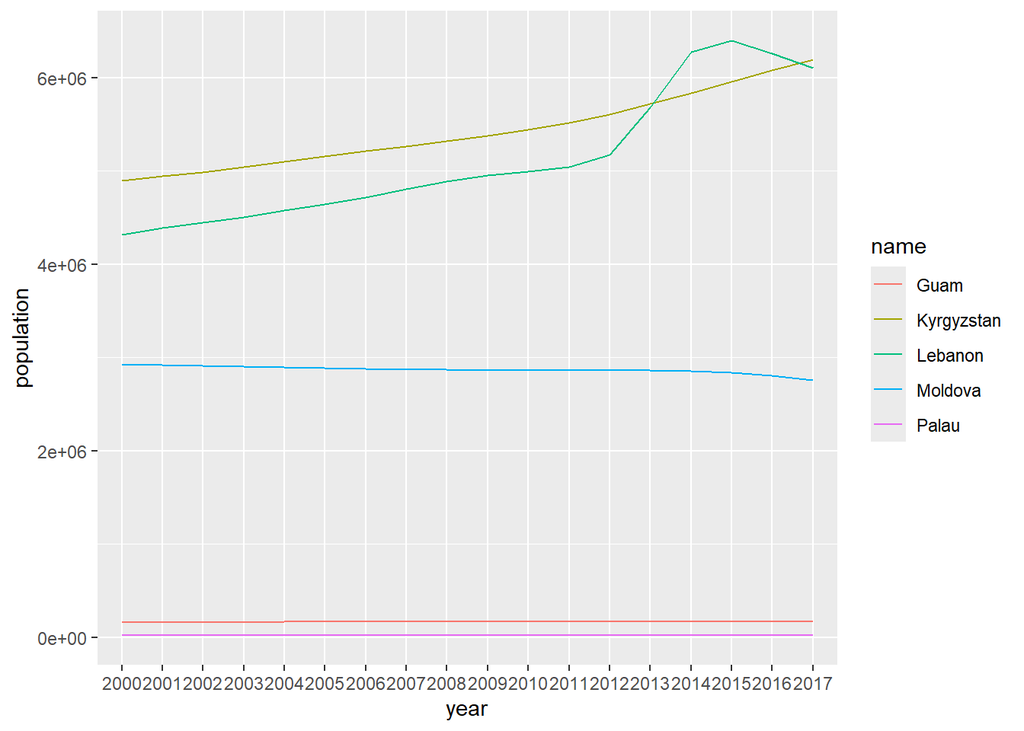

```r
tot_pop |>
  filter(name == "Palau" | name == "Lebanon" | name == "Kyrgyzstan" | name == "Guam" | name == "Moldova")  |>
  pivot_longer(
    cols = !name,
    names_to = "year",
    values_to = "population"
  ) |>
  ggplot(aes(x = year, y = population, color = name, group = name)) +
  geom_line()
```

```r
urb_grow
```

```
# A tibble: 266 × 19
   name   `2000` `2001` `2002` `2003` `2004` `2005`  `2006` `2007` `2008` `2009`
   <chr>   <dbl>  <dbl>  <dbl>  <dbl>  <dbl>  <dbl>   <dbl>  <dbl>  <dbl>  <dbl>
 1 Aruba   1.66   0.956  0.401  0.197 0.0946  0.194  0.367   0.408  0.413  0.402
 2 AFE     3.60   3.66   3.72   3.71  3.74    3.81   3.81    3.61   4.12   4.11
 3 Afgha…  1.86   1.15   6.86   7.95  4.59    4.47   5.03    2.69   2.89   4.45
 4 AFW     4.15   4.57   4.56   4.56  4.56    4.57   4.56    4.52   4.49   4.48
 5 Angola  5.65   5.63   5.62   5.65  5.69    5.67   4.95    4.97   4.98   4.98
 6 Alban…  0.742  0.710  2.18   2.06  1.97    1.83   1.66    1.49   1.44   1.47
 7 Andor…  0.377  2.21   3.92   3.75  3.51    3.18  -0.0375 -3.15  -3.08  -3.04
 8 ARB     2.76   2.74   2.70   2.69  2.68    2.98   3.29    3.21   3.53   3.44
 9 Unite…  6.11   5.84   5.57   5.33  5.10    7.43  14.0    18.6   17.8   13.8
10 Argen…  1.35   1.31   1.28   1.23  1.21    1.22   1.22    1.19   1.17   1.19
# ℹ 256 more rows
# ℹ 8 more variables: `2010` <dbl>, `2011` <dbl>, `2012` <dbl>, `2013` <dbl>,
#   `2014` <dbl>, `2015` <dbl>, `2016` <dbl>, `2017` <dbl>
```

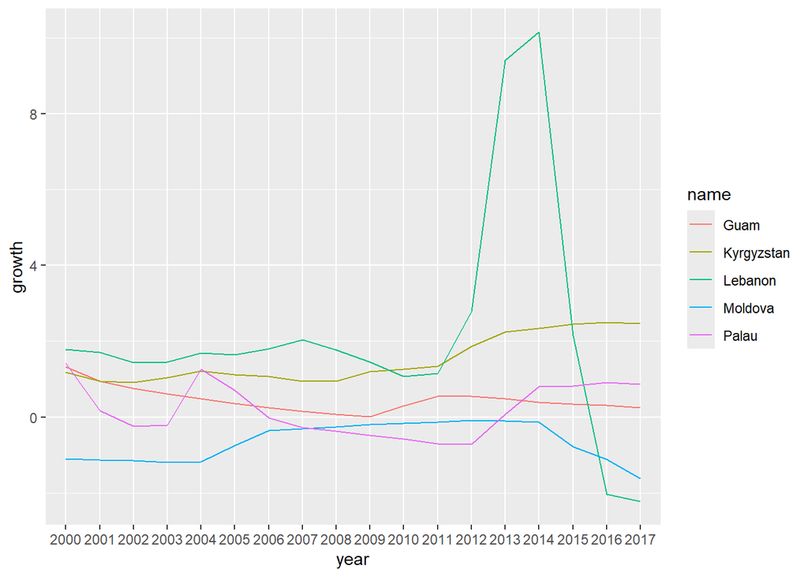

```r
urb_grow |>
  filter(name == "Palau" | name == "Lebanon" | name == "Kyrgyzstan" | name == "Guam" | name == "Moldova")  |>
  pivot_longer(
    cols = !name,
    names_to = "year",
    values_to = "growth"
  ) |>
  ggplot(aes(x = year, y = growth, color = name, group = name)) +
  geom_line()
```

Lebanon had a significant increase in its urban growth from 2012 to 2014 which corresponds to a significant increase in overall total population on the graph above. Similarly, Kyrgyzstan has an overall slight increase in their total population and the graph shows a similar slight increase in urban growth, however it is not as sharp a spike/increase as Lebanon. The other countries selected are very small total populations that do not increase in overall total population, even though curiously Palau has two increases in urban growth, they did not significantly impact total population. Another striking result is the slight decline in total population in Moldova, which can be seen throughout the dataset regardless of their urban growth rate increasing at one time. However a significant decrease in population can also be see from 2014 to 2017 and the urban growth rate drops with it.